# Example Meta Analysis Script

Teresa Ober

July 8, 2021

# Useful Links

- [*Return to workshop main page*](https://tmober.github.io/meta-workshop)
- *Meta-analysis R Script*:  
  – R script: [example-meta-analysis-script.R](https://drive.google.com/file/d/1xT1ihvlKSt_-a-j1wPGpna-9FTAHWfjK/)  
  – Rmarkdown script: [example-meta-analysis-script.Rmd](https://drive.google.com/file/d/1eUm6YTlH3zCF1WmLO-gcFHi589aCGzNQ/)
- *Data file*: [ober_2020_ef_decoding.csv](https://drive.google.com/file/d/1YykZF5iP0U6003c9UJeSsK-9K4h0-i8F/)

# 1. Set things up

## Install packages using the pacman package

```r
if (!require("pacman")) install.packages("pacman")
pacman::p_load(tidyverse, dplyr, googlesheets, metafor, robumeta, ggplot2)
```

## Import the data

### From Google Sheets

```r
key <- gs_key("1YNw25mC50vlQ1iMYt7d7FgGHCh1b6pZeKHuowFl5BDE")
ef_decod_raw_data <- gs_read(key, ws = "ober_2020_ef_decoding",
                     col_types = cols(
                       `Study` = col_character(),
                       `Author` = col_character(),
                       `PubYear` = col_integer(),
                       `Country` = col_character(),
                       `PubPeerRev0` = col_integer(),
                       `JrnlCiteScore_2018` = col_double(),
                       `StudyDesign` = col_character(),
                       `LangEng0` = col_double(),
                       `WritingSystem` = col_character(),
                       `MeanAgeYears` = col_double(),
                       `NSubjects` = col_double(),
                       `WordDec0` = col_integer(),
                       `NWordDec0` = col_integer(),
                       `WorkMem0` = col_integer(),
                       `TaskSwitch0` = col_integer(),
                       `InhibCont0` = col_integer(),
                       `Verbal0NV1` = col_integer(),
                       `r` = col_double()
                       ), fileEncoding = "UTF-8-BOM") %>%
  as.data.frame()


# read.csv("ober_2020_ef_decoding.csv")
```

# From .csv

Alternatively, you can also download the .csv file, and import it as follows

```r
read.csv("ober_2020_ef_decoding.csv")
```

# 2. Calculate effect sizes

Calculate effect size and variances using *escalc()* function from *metafor* package. IN this case, we are simply transforming the correlation coefficient using Fisher’s r-to-Z transformation.

```r
ef_decod_data <- escalc(measure = "ZCOR",        # we are generating Fisher's Z-transofrmed correlation values
                    ri = r,                      # the inputted r values
                    ni = NSubjects,              # column containing total sample size
                    data = ef_decod_raw_data,    # dataframe
                    slab = Study)                # study labels
```

# 3. Visually inspect data for potential outliers

Check for outliers with violin plot. In this case, the violin plot does not seem to indicate the presence of any obvious outliers.

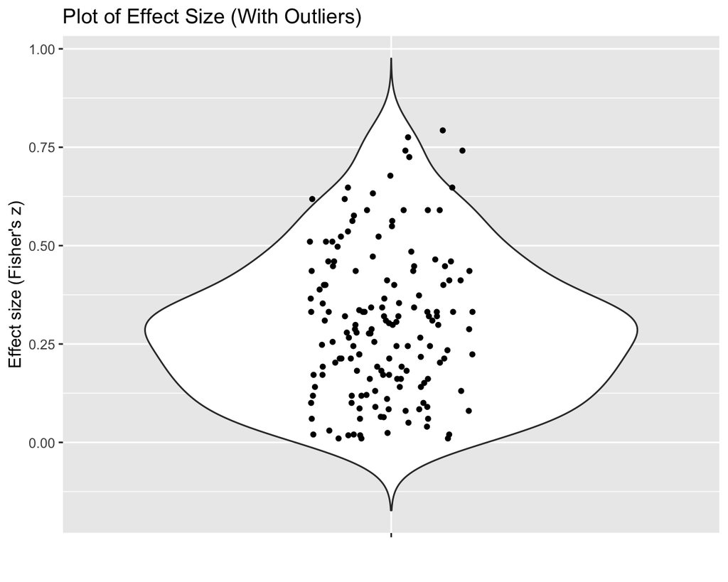

```r
ggplot(ef_decod_data, aes(x='', y = yi)) +
  geom_violin(trim=FALSE) +
  geom_jitter(shape=16, position=position_jitter(0.15)) +
  labs(title="Plot of Effect Size (With Outliers)", x="", y = "Effect size (Fisher's z)")
```

# 4. Run the main meta-analytic model

## Fit the random effects model with no moderators without accounting for study interdependencies using *metafor*

```r
model_metafor <- rma(yi = yi,
                     vi = vi,
                     data = ef_decod_data,
                     method = "REML",
                     level = 95,
                     digits = 7,
                     slab = Study)
model_metafor
```

```
##
## Random-Effects Model (k = 157; tau^2 estimator: REML)
##
## tau^2 (estimated amount of total heterogeneity): 0.0222585 (SE = 0.0037329)
## tau (square root of estimated tau^2 value):      0.1491929
## I^2 (total heterogeneity / total variability):   75.29%
## H^2 (total variability / sampling variability):  4.05
##
## Test for Heterogeneity:
## Q(df = 156) = 703.6844866, p-val < .0000001
##
## Model Results:
##
##  estimate         se        zval       pval      ci.lb      ci.ub
## 0.2916225  0.0146871  19.8556687  <.0000001  0.2628362  0.3204087  ***
##
## ---
## Signif. codes:  0 '***' 0.001 '**' 0.01 '*' 0.05 '.' 0.1 ' ' 1
```

Note:  
- method = “REML”: restricted maximum likelihood  
- level = 95: CI  
- digits = 7: decimal points  
- slab = Study: study labels

## Fit the random effects model with no moderators accounting for effect size interdependencies using *metafor*

```r
model_metafor_mv <- rma.mv(yi = yi,
                           V = vi,
                           data = ef_decod_data,
                           method = "REML",
                           level = 95,
                           digits = 7,
                           slab = Study,
                           random = ~ 1 | Study)
model_metafor_mv
```

```
##
## Multivariate Meta-Analysis Model (k = 157; method: REML)
##
## Variance Components:
##
##                estim       sqrt  nlvls  fixed  factor
## sigma^2    0.0189081  0.1375067     64     no   Study
##
## Test for Heterogeneity:
## Q(df = 156) = 703.6844866, p-val < .0000001
##
## Model Results:
##
##  estimate         se        zval       pval      ci.lb      ci.ub
## 0.3228548  0.0202081  15.9764935  <.0000001  0.2832476  0.3624620  ***
##
## ---
## Signif. codes:  0 '***' 0.001 '**' 0.01 '*' 0.05 '.' 0.1 ' ' 1
```

Note:  
- random = ~ 1 | Study: multilevel model to handle sample dependency (can also use “Author” if it makes more sense to do so)

```r
model_robu <- robu(yi ~ 1,
                   var.eff.size = vi,
                   data = ef_decod_data,
                   modelweights = "CORR",
                   studynum = Study,
                   small = TRUE)
print(model_robu, digits = 7)
```

```
## RVE: Correlated Effects Model with Small-Sample Corrections
##
## Model: yi ~ 1
##
## Number of studies = 64
## Number of outcomes = 157 (min = 1 , mean = 2.45 , median = 2 , max = 12 )
## Rho = 0.8
## I.sq = 78.14545
## Tau.sq = 0.02625059
##
##                 Estimate     StdErr  t-value      dfs P(|t|>) 95% CI.L
## 1 X.Intercept. 0.3238877 0.02044622 15.84096 59.70201       0 0.282985
##    95% CI.U Sig
## 1 0.3647904 ***
## ---
## Signif. codes: < .01 *** < .05 ** < .10 *
## ---
## Note: If df < 4, do not trust the results
```

Note:  
- modelweights = “CORR”: assumes model weights are correlated (“CORR”) rather than hierarchical (“HIER”). See Hedges, Tipton and Johnson (2010) and Tipton (2013) for extended explanations of each weighting scheme  
- studynum = Study: study labels  
- small = TRUE: used to fit the meta-regression models with the small- sample corrections for both the residuals and degrees of freedom, as detailed in Tipton (2013)

# 5. Calculate heterogeneity

## Calculate the I^2 statistic for a multilevel model

Using the formula from www.metafor-project.org/doku.php/tips:i2_multilevel_multivariate

```r
W <- diag(1/ef_decod_data$vi)
X <- model.matrix(model_metafor_mv)
P <- W - W %*%
  X %*% solve(t(X) %*% W %*% X) %*%
  t(X) %*% W

I2_statistic <- 100 * sum(model_metafor_mv$sigma2) / (sum(model_metafor_mv$sigma2) +
                                                  (model_metafor_mv$k-model_metafor_mv$p)/sum(diag(P)))
I2_statistic
```

```
## [1] 72.12903
```

# 6. Check for influential points

## Using standardized residuals of correlations

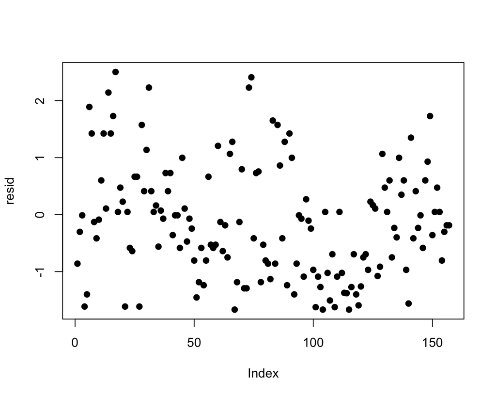

```r
resid <- residuals(model_metafor_mv) %>%
  scale(center = FALSE, scale = TRUE)      # convert residuals to z-scores

plot(resid, type="p", pch=19)
```

```r
outliers_resid <- resid %>%
  cbind(ef_decod_data$Study) %>%            # bind study names for reference
  subset(resid > 3.0 | resid < - 3.0)       # subset outliers
outliers_resid
```

```
##      [,1] [,2]
```

In this case, we actually do not appear to have any influential points based on the standardized residuals of correlations.

## Using Cook’s distance

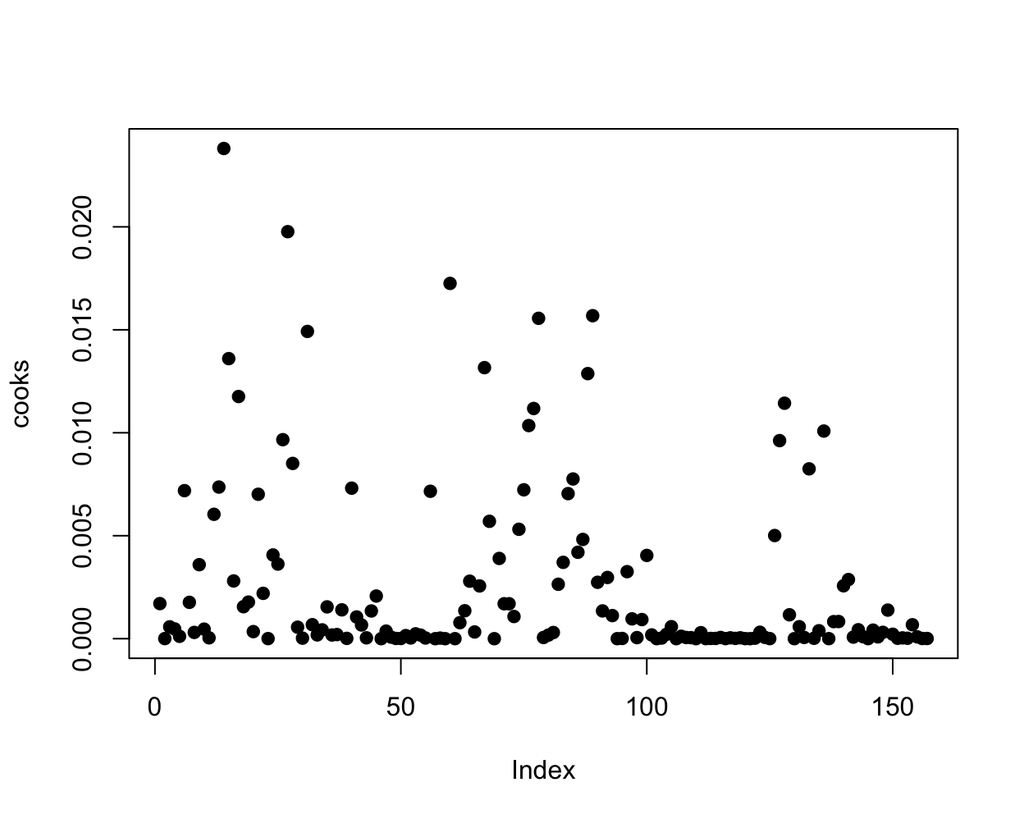

```r
cooks <- cooks.distance(model_metafor_mv)

plot(cooks, type="p", pch=19)
```

```r
# View outliers with Cooks > 0.50
outliers_cooks <- cooks %>%
  cbind(ef_decod_data$Study) %>%           # bind study names for reference
  subset(cooks > 0.50)                     # subset outliers
outliers_cooks
```

```
##      .
```

```r
# Create new dataframe with outliers removed
ef_decod_data_no_outliers <- ef_decod_data %>%
  cbind(cooks) %>%
  filter(cooks < 3.0*mean(cooks))
```

Once again, it looks we actually do no have any influential points based on Cook’s Distance.

# 7. Create forest plot

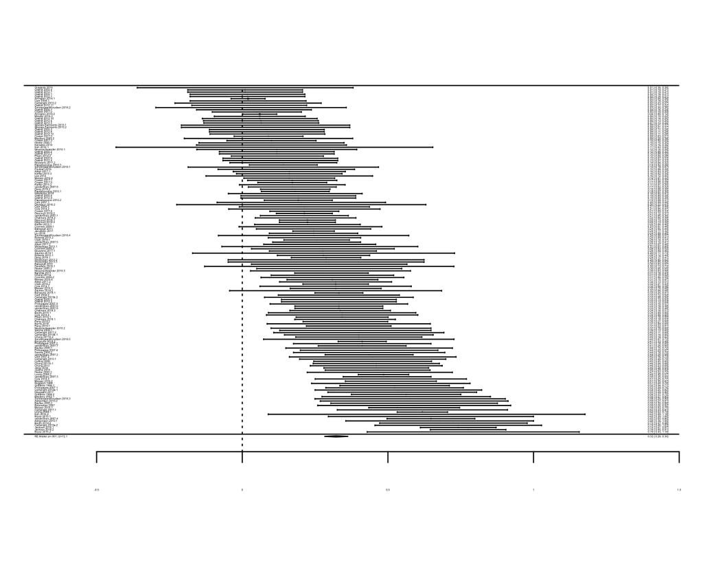

```r
forest(model_metafor_mv,
       xlim = c(-.75, 1.25),                  # adjust horizontal plot region limits
       order ="obs",                          # order by effect size
       addfit = TRUE,                         # add standard summary polygon
       annotate = TRUE,                       # remove annotations
       # width = 0,                           # width of annotations
       # efac = .55,                          # height of CI bars
       # pch = 19,                            # changing point symbol to filled circle
       # col = "gray40",                      # change color of points/CIs
       # clim = c(-1 ,1),                     # set absolute limits for CIs
       # cex.lab = 1,                         # increase size of x-axis title
       # cex.axis = 1,                        # increase size of x-axis labels
       # cex = .85,                           # set font expansion factor
       lty = c("solid",                       # CI line type
               "solid",                       # credibility interval line type
               "solid"),                      # horizontal line type
       xlab = "",                             # label X axis
       mlab = "RE Model: p<.001, I2=72.1",    # label summary estimate
       showweights = FALSE,                   # include weights given to effects in model fitting
       steps = 5)                             # number of tick marks for the x-axis
```

## Re-run forest plot with median effect size estimates per study

Since the previous plot may be difficult to read, we may want to aggregate effect size estimates within each study. The plot below shows only the median effect size for each study. This is not exactly accurate, but does help in creating a simple illustration of the variation in effect sizes between studies.

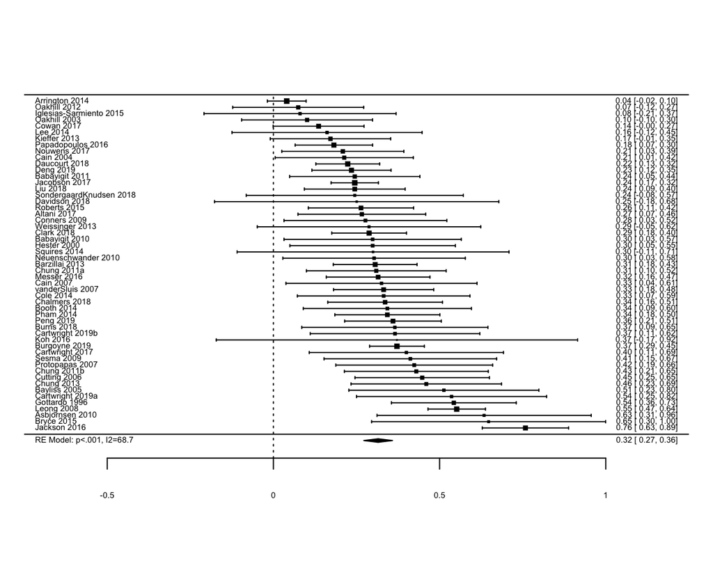

# 8. Run moderator analyses

## Test moderator 1 (e.g., type of decoding task)

```r
model_moderator1 <-  rma.mv(yi = yi,
                       V = vi,
                       mods = ~ WordDec0, # allows post hoc tests
                       data = ef_decod_data_no_outliers,
                       random = ~ 1 | Study)
model_moderator1
```

```
##
## Multivariate Meta-Analysis Model (k = 139; method: REML)
##
## Variance Components:
##
##             estim    sqrt  nlvls  fixed  factor
## sigma^2    0.0171  0.1309     53     no   Study
##
## Test for Residual Heterogeneity:
## QE(df = 137) = 580.4195, p-val < .0001
##
## Test of Moderators (coefficient 2):
## QM(df = 1) = 0.0771, p-val = 0.7813
##
## Model Results:
##
##           estimate      se     zval    pval    ci.lb   ci.ub
## intrcpt     0.3153  0.0227  13.8808  <.0001   0.2708  0.3598  ***
## WordDec0   -0.0079  0.0283  -0.2776  0.7813  -0.0634  0.0477
##
## ---
## Signif. codes:  0 '***' 0.001 '**' 0.01 '*' 0.05 '.' 0.1 ' ' 1
```

## Test moderator 2 (e.g., whether verbal or non-verbal stimuli were used)

```r
model_moderator2 <-  rma.mv(yi = yi,
                      V = vi,
                      mods = ~ Verbal0NV1,
                      data = ef_decod_data_no_outliers,
                      random = ~ 1 | Study)
model_moderator2
```

```
##
## Multivariate Meta-Analysis Model (k = 139; method: REML)
##
## Variance Components:
##
##             estim    sqrt  nlvls  fixed  factor
## sigma^2    0.0166  0.1287     53     no   Study
##
## Test for Residual Heterogeneity:
## QE(df = 137) = 595.0809, p-val < .0001
##
## Test of Moderators (coefficient 2):
## QM(df = 1) = 0.6904, p-val = 0.4060
##
## Model Results:
##
##             estimate      se     zval    pval    ci.lb   ci.ub
## intrcpt       0.3178  0.0217  14.6484  <.0001   0.2753  0.3603  ***
## Verbal0NV1   -0.0213  0.0257  -0.8309  0.4060  -0.0717  0.0290
##
## ---
## Signif. codes:  0 '***' 0.001 '**' 0.01 '*' 0.05 '.' 0.1 ' ' 1
```

# 9. Test for biases

## Using published vs unpublished

```r
model_published <- rma.mv(yi = yi,
                          V = vi,
                          mods = ~ factor(PubPeerRev0),
                          data = ef_decod_data_no_outliers,
                          random = ~ 1 | Study)
model_published
```

```
##
## Multivariate Meta-Analysis Model (k = 139; method: REML)
##
## Variance Components:
##
##             estim    sqrt  nlvls  fixed  factor
## sigma^2    0.0162  0.1273     53     no   Study
##
## Test for Residual Heterogeneity:
## QE(df = 137) = 585.0127, p-val < .0001
##
## Test of Moderators (coefficient 2):
## QM(df = 1) = 1.5314, p-val = 0.2159
##
## Model Results:
##
##                       estimate      se     zval    pval    ci.lb   ci.ub
## intrcpt                 0.3005  0.0228  13.1665  <.0001   0.2558  0.3452  ***
## factor(PubPeerRev0)1    0.0662  0.0535   1.2375  0.2159  -0.0386  0.1710
##
## ---
## Signif. codes:  0 '***' 0.001 '**' 0.01 '*' 0.05 '.' 0.1 ' ' 1
```

## Using journal cite score

```r
model_citescore <- rma.mv(yi = yi,
                          V = vi,
                        mods = JrnlCiteScore_2018,
                        data = ef_decod_data_no_outliers,
                        random = ~ 1 | Study)
model_citescore
```

```
##
## Multivariate Meta-Analysis Model (k = 115; method: REML)
##
## Variance Components:
##
##             estim    sqrt  nlvls  fixed  factor
## sigma^2    0.0117  0.1082     41     no   Study
##
## Test for Residual Heterogeneity:
## QE(df = 113) = 340.3321, p-val < .0001
##
## Test of Moderators (coefficient 2):
## QM(df = 1) = 0.8544, p-val = 0.3553
##
## Model Results:
##
##          estimate      se    zval    pval    ci.lb   ci.ub
## intrcpt    0.2469  0.0499  4.9515  <.0001   0.1492  0.3447  ***
## mods       0.0005  0.0006  0.9243  0.3553  -0.0006  0.0017
##
## ---
## Signif. codes:  0 '***' 0.001 '**' 0.01 '*' 0.05 '.' 0.1 ' ' 1
```

## Using trim-and-fill analysis

We will need to use the simple model without accounting for clustering since *trimfill()* does not work well with multivariate models.

```r
model_metafor_no_outliers <- rma(yi = yi,
                                 vi = vi,
                                 data = ef_decod_data_no_outliers)
```

Create funnel plot (with trim and fill)

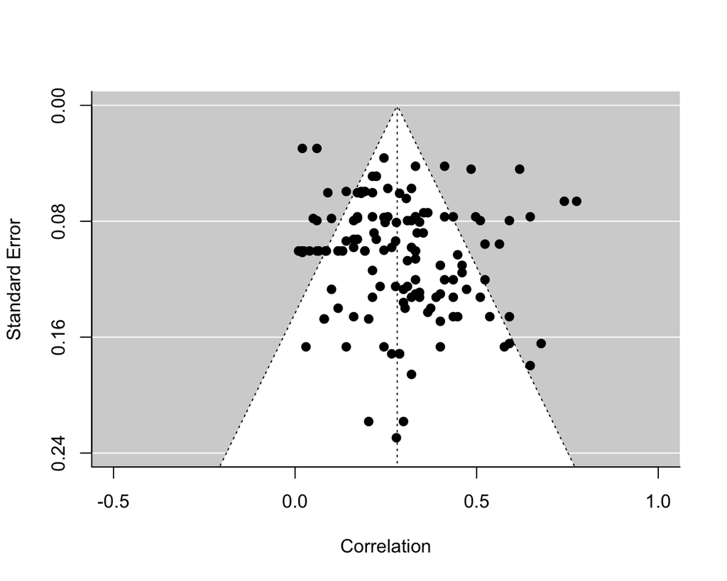

```r
taf <- trimfill(model_metafor_no_outliers) # estimate missing studies
funnel(taf,                                # add missing studies to plot
       xlim=c(-.5,1),
       xlab= "Correlation",
       ylim = c(.24, 0),
       steps = 4,
       digits = c(1, 2))
```